# Venezuela Tweet Clean Up & Analysis

Brian and Ash

April 16, 2018

Ensure that the following packages are installed and loaded:“twitteR”, “rtweet”, “dplyr”, “tidyr”

## Environment Set Up

Information needed to pull data from twitter: CONSUMER_KEY, CONSUMER SECRET,ACCESS_TOKEN, ACCESS_SECRET. This willl vary based on your own twitter account.

Creates the authetication to the twitter API, without a valid authentication the twitter pulls will fail.

```r
setup_twitter_oauth(consumer_key, consumer_secret, access_token, access_secret)
```

```
## [1] "Using direct authentication"
```

Set Up Path. Ensure to change the variable myPath with your own path accordingly.

## Getting and Appending Data

Read the data that has been saved previously, to ensure that we can append new data.

```r
test <- read.csv(paste(myPath,"tweets.df.all.csv", sep=""), header = TRUE,stringsAsFactors = FALSE)
str(test)
```

```
## 'data.frame':    185898 obs. of  17 variables:
##  $ text         : chr  "RT @VatoRegio69: Enmascarados, maduro chingándose a chavito. Si quieres verga, la aguantas cabrón. https://t.co/dnYRDAF97m" "RT @DanielBlancoPz: Smartmatic cerró operaciones en Venezuela debido al fraude cometido por el Centro Nacional "| __truncated__ "Florida aprobó proy…
##  $ favorited    : logi  FALSE FALSE FALSE FALSE FALSE FALSE ...
##  $ favoriteCount: int  0 0 0 0 0 0 0 0 0 0 ...
##  $ replyToSN    : chr  NA NA NA NA ...
##  $ created      : chr  "2018-03-09 00:20:00" "2018-03-09 00:20:00" "2018-03-09 00:20:00" "2018-03-09 00:20:00" ...
##  $ truncated    : logi  FALSE FALSE FALSE FALSE FALSE FALSE ...
##  $ replyToSID   : num  NA NA NA NA NA NA NA NA NA NA ...
##  $ id           : num  9.72e+17 9.72e+17 9.72e+17 9.72e+17 9.72e+17 ...
##  $ replyToUID   : num  NA NA NA NA NA NA NA NA NA NA ...
##  $ statusSource : chr  "<a href=\"http://twitter.com/download/android\" rel=\"nofollow\">Twitter for Android</a>" "<a href=\"https://mobile.twitter.com\" rel=\"nofollow\">Twitter Lite</a>" "<a href=\"http://publicize.wp.com/\" rel=\"nofollow\">WordPress.com</a>" "<a href=\"http://twitter.com\" re…
##  $ screenName   : chr  "Rubielhg" "giusyff" "NoticiasVenezue" "sordoiturriza" ...
##  $ retweetCount : int  182 2640 0 0 30 3 457 1041 275 0 ...
##  $ isRetweet    : logi  TRUE TRUE FALSE FALSE TRUE TRUE ...
##  $ retweeted    : logi  FALSE FALSE FALSE FALSE FALSE FALSE ...
##  $ longitude    : num  NA NA NA NA NA NA NA NA NA NA ...
##  $ latitude     : num  NA NA NA NA NA NA NA NA NA NA ...
##  $ source_data  : chr  "tweets.df500" "tweets.df500" "tweets.df500" "tweets.df500" ...
```

Converts the created column into a Date Type instead of Character.

```r
#test <- mutate(test,created = as.POSIXct(test$created, format ="%m/%d/%Y %H:%M"))
test <- mutate(test,created = as.POSIXct(test$created))
```

Ensure that there are no NAs in the Created field.

```r
str(test)
```

```
## 'data.frame':    185898 obs. of  17 variables:
##  $ text         : chr  "RT @VatoRegio69: Enmascarados, maduro chingándose a chavito. Si quieres verga, la aguantas cabrón. https://t.co/dnYRDAF97m" "RT @DanielBlancoPz: Smartmatic cerró operaciones en Venezuela debido al fraude cometido por el Centro Nacional "| __truncated__ "Florida aprobó proy…
##  $ favorited    : logi  FALSE FALSE FALSE FALSE FALSE FALSE ...
##  $ favoriteCount: int  0 0 0 0 0 0 0 0 0 0 ...
##  $ replyToSN    : chr  NA NA NA NA ...
##  $ created      : POSIXct, format: "2018-03-09 00:20:00" "2018-03-09 00:20:00" ...
##  $ truncated    : logi  FALSE FALSE FALSE FALSE FALSE FALSE ...
##  $ replyToSID   : num  NA NA NA NA NA NA NA NA NA NA ...
##  $ id           : num  9.72e+17 9.72e+17 9.72e+17 9.72e+17 9.72e+17 ...
##  $ replyToUID   : num  NA NA NA NA NA NA NA NA NA NA ...
##  $ statusSource : chr  "<a href=\"http://twitter.com/download/android\" rel=\"nofollow\">Twitter for Android</a>" "<a href=\"https://mobile.twitter.com\" rel=\"nofollow\">Twitter Lite</a>" "<a href=\"http://publicize.wp.com/\" rel=\"nofollow\">WordPress.com</a>" "<a href=\"http://twitter.com\" re…
##  $ screenName   : chr  "Rubielhg" "giusyff" "NoticiasVenezue" "sordoiturriza" ...
##  $ retweetCount : int  182 2640 0 0 30 3 457 1041 275 0 ...
##  $ isRetweet    : logi  TRUE TRUE FALSE FALSE TRUE TRUE ...
##  $ retweeted    : logi  FALSE FALSE FALSE FALSE FALSE FALSE ...
##  $ longitude    : num  NA NA NA NA NA NA NA NA NA NA ...
##  $ latitude     : num  NA NA NA NA NA NA NA NA NA NA ...
##  $ source_data  : chr  "tweets.df500" "tweets.df500" "tweets.df500" "tweets.df500" ...
```

```r
test[is.na(test$created),]
```

```
##  [1] text          favorited     favoriteCount replyToSN     created
##  [6] truncated     replyToSID    id            replyToUID    statusSource
## [11] screenName    retweetCount  isRetweet     retweeted     longitude
## [16] latitude      source_data
## <0 rows> (or 0-length row.names)
```

```r
tweets3000_daily <- searchTwitter("Venezuela OR #Venezuela OR Maduro OR #Maduro", n = 3000, retryOnRateLimit = 120 )
```

Convert the pulled tweets, which are class type list, from the previous step into a Data Frame in order to analyze the data.

```r
tweets.df3000 <- twListToDF(tweets3000_daily)
```

We need to add a column to each data frame that adds the date the tweet was pulled. We store this in a new variable so we won’t edit the source.

```r
tweets.df3000.ec <- mutate(tweets.df3000,source_data=date())
```

Append the recently pulled data with the previously loaded data.

```r
test_upd <- rbind(test,tweets.df3000.ec)
```

Quickly analyze the newly appended data frame

```r
str(test_upd)
```

```
## 'data.frame':    188898 obs. of  17 variables:
##  $ text         : chr  "RT @VatoRegio69: Enmascarados, maduro chingándose a chavito. Si quieres verga, la aguantas cabrón. https://t.co/dnYRDAF97m" "RT @DanielBlancoPz: Smartmatic cerró operaciones en Venezuela debido al fraude cometido por el Centro Nacional "| __truncated__ "Florida aprobó proy…
##  $ favorited    : logi  FALSE FALSE FALSE FALSE FALSE FALSE ...
##  $ favoriteCount: num  0 0 0 0 0 0 0 0 0 0 ...
##  $ replyToSN    : chr  NA NA NA NA ...
##  $ created      : POSIXct, format: "2018-03-09 00:20:00" "2018-03-09 00:20:00" ...
##  $ truncated    : logi  FALSE FALSE FALSE FALSE FALSE FALSE ...
##  $ replyToSID   : chr  NA NA NA NA ...
##  $ id           : chr  "9.72e+17" "9.72e+17" "9.72e+17" "9.72e+17" ...
##  $ replyToUID   : chr  NA NA NA NA ...
##  $ statusSource : chr  "<a href=\"http://twitter.com/download/android\" rel=\"nofollow\">Twitter for Android</a>" "<a href=\"https://mobile.twitter.com\" rel=\"nofollow\">Twitter Lite</a>" "<a href=\"http://publicize.wp.com/\" rel=\"nofollow\">WordPress.com</a>" "<a href=\"http://twitter.com\" re…
##  $ screenName   : chr  "Rubielhg" "giusyff" "NoticiasVenezue" "sordoiturriza" ...
##  $ retweetCount : num  182 2640 0 0 30 ...
##  $ isRetweet    : logi  TRUE TRUE FALSE FALSE TRUE TRUE ...
##  $ retweeted    : logi  FALSE FALSE FALSE FALSE FALSE FALSE ...
##  $ longitude    : chr  NA NA NA NA ...
##  $ latitude     : chr  NA NA NA NA ...
##  $ source_data  : chr  "tweets.df500" "tweets.df500" "tweets.df500" "tweets.df500" ...
```

We confirm that there are no N/As in the created column. Should result in 0 rows.

```r
test_upd[is.na(test_upd$created),]
```

```
##  [1] text          favorited     favoriteCount replyToSN     created
##  [6] truncated     replyToSID    id            replyToUID    statusSource
## [11] screenName    retweetCount  isRetweet     retweeted     longitude
## [16] latitude      source_data
## <0 rows> (or 0-length row.names)
```

Remove duplicates based on text, created, screenName, statusSource.

```r
test_rmv_dups <- distinct(test_upd, text, created, screenName,statusSource,.keep_all = TRUE)
str(test_rmv_dups)
```

```
## 'data.frame':    188898 obs. of  17 variables:
##  $ text         : chr  "RT @VatoRegio69: Enmascarados, maduro chingándose a chavito. Si quieres verga, la aguantas cabrón. https://t.co/dnYRDAF97m" "RT @DanielBlancoPz: Smartmatic cerró operaciones en Venezuela debido al fraude cometido por el Centro Nacional "| __truncated__ "Florida aprobó proy…
##  $ favorited    : logi  FALSE FALSE FALSE FALSE FALSE FALSE ...
##  $ favoriteCount: num  0 0 0 0 0 0 0 0 0 0 ...
##  $ replyToSN    : chr  NA NA NA NA ...
##  $ created      : POSIXct, format: "2018-03-09 00:20:00" "2018-03-09 00:20:00" ...
##  $ truncated    : logi  FALSE FALSE FALSE FALSE FALSE FALSE ...
##  $ replyToSID   : chr  NA NA NA NA ...
##  $ id           : chr  "9.72e+17" "9.72e+17" "9.72e+17" "9.72e+17" ...
##  $ replyToUID   : chr  NA NA NA NA ...
##  $ statusSource : chr  "<a href=\"http://twitter.com/download/android\" rel=\"nofollow\">Twitter for Android</a>" "<a href=\"https://mobile.twitter.com\" rel=\"nofollow\">Twitter Lite</a>" "<a href=\"http://publicize.wp.com/\" rel=\"nofollow\">WordPress.com</a>" "<a href=\"http://twitter.com\" re…
##  $ screenName   : chr  "Rubielhg" "giusyff" "NoticiasVenezue" "sordoiturriza" ...
##  $ retweetCount : num  182 2640 0 0 30 ...
##  $ isRetweet    : logi  TRUE TRUE FALSE FALSE TRUE TRUE ...
##  $ retweeted    : logi  FALSE FALSE FALSE FALSE FALSE FALSE ...
##  $ longitude    : chr  NA NA NA NA ...
##  $ latitude     : chr  NA NA NA NA ...
##  $ source_data  : chr  "tweets.df500" "tweets.df500" "tweets.df500" "tweets.df500" ...
```

Ensuring that there are no NAs in the Created column

```r
test_rmv_dups[is.na(test_rmv_dups$created),]
```

```
##  [1] text          favorited     favoriteCount replyToSN     created
##  [6] truncated     replyToSID    id            replyToUID    statusSource
## [11] screenName    retweetCount  isRetweet     retweeted     longitude
## [16] latitude      source_data
## <0 rows> (or 0-length row.names)
```

Store the tweets with the duplicates removed

```r
write.csv(test_rmv_dups, file = (paste(myPath,"tweets.df.all.csv", sep="")),row.names=FALSE)
```

## Cleaning the Data

Looking at the StatusSource variable, it has the following format:

```r
head(select(test_rmv_dups,statusSource),5)
```

```
##                                                                           statusSource
## 1 <a href="http://twitter.com/download/android" rel="nofollow">Twitter for Android</a>
## 2                 <a href="https://mobile.twitter.com" rel="nofollow">Twitter Lite</a>
## 3                  <a href="http://publicize.wp.com/" rel="nofollow">WordPress.com</a>
## 4                   <a href="http://twitter.com" rel="nofollow">Twitter Web Client</a>
## 5   <a href="http://twitter.com/download/iphone" rel="nofollow">Twitter for iPhone</a>
```

Seperate statusSource based on the sep > in order to see the platform of the Tweet (Android, Iphone, Ipad)

```r
test_rmv_dups_sep <- separate(test_rmv_dups,statusSource, c("URL","Platform"),sep=">")
head(select(test_rmv_dups_sep,URL, Platform),5)
```

```
##                                                            URL
## 1 <a href="http://twitter.com/download/android" rel="nofollow"
## 2          <a href="https://mobile.twitter.com" rel="nofollow"
## 3            <a href="http://publicize.wp.com/" rel="nofollow"
## 4                  <a href="http://twitter.com" rel="nofollow"
## 5  <a href="http://twitter.com/download/iphone" rel="nofollow"
##                 Platform
## 1 Twitter for Android</a
## 2        Twitter Lite</a
## 3       WordPress.com</a
## 4  Twitter Web Client</a
## 5  Twitter for iPhone</a
```

We need to continue the clean up of the Platform column by removing the additional characters at the end.

```r
test_rmv_dups_sep1 <- separate(test_rmv_dups_sep,Platform, c("Platform","Remove"),sep="<")
head(select(test_rmv_dups_sep1,Platform, Remove),5)
```

```
##              Platform Remove
## 1 Twitter for Android     /a
## 2        Twitter Lite     /a
## 3       WordPress.com     /a
## 4  Twitter Web Client     /a
## 5  Twitter for iPhone     /a
```

Remove the unnecasarry columns that resulted from separating statusSource.

```r
test_rmv_dups_sep2 <- select(test_rmv_dups_sep1,-URL,-Remove)
str(test_rmv_dups_sep2)
```

```
## 'data.frame':    188898 obs. of  17 variables:
##  $ text         : chr  "RT @VatoRegio69: Enmascarados, maduro chingándose a chavito. Si quieres verga, la aguantas cabrón. https://t.co/dnYRDAF97m" "RT @DanielBlancoPz: Smartmatic cerró operaciones en Venezuela debido al fraude cometido por el Centro Nacional "| __truncated__ "Florida aprobó proy…
##  $ favorited    : logi  FALSE FALSE FALSE FALSE FALSE FALSE ...
##  $ favoriteCount: num  0 0 0 0 0 0 0 0 0 0 ...
##  $ replyToSN    : chr  NA NA NA NA ...
##  $ created      : POSIXct, format: "2018-03-09 00:20:00" "2018-03-09 00:20:00" ...
##  $ truncated    : logi  FALSE FALSE FALSE FALSE FALSE FALSE ...
##  $ replyToSID   : chr  NA NA NA NA ...
##  $ id           : chr  "9.72e+17" "9.72e+17" "9.72e+17" "9.72e+17" ...
##  $ replyToUID   : chr  NA NA NA NA ...
##  $ Platform     : chr  "Twitter for Android" "Twitter Lite" "WordPress.com" "Twitter Web Client" ...
##  $ screenName   : chr  "Rubielhg" "giusyff" "NoticiasVenezue" "sordoiturriza" ...
##  $ retweetCount : num  182 2640 0 0 30 ...
##  $ isRetweet    : logi  TRUE TRUE FALSE FALSE TRUE TRUE ...
##  $ retweeted    : logi  FALSE FALSE FALSE FALSE FALSE FALSE ...
##  $ longitude    : chr  NA NA NA NA ...
##  $ latitude     : chr  NA NA NA NA ...
##  $ source_data  : chr  "tweets.df500" "tweets.df500" "tweets.df500" "tweets.df500" ...
```

## Manipulating the Data

Create a DF with only the Platform used

```r
commonPlatform <- select(test_rmv_dups_sep2,Platform)
```

Create a variable that holds the frequency of the common platforms used Source: https://stackoverflow.com/questions/24576515/relative-frequencies-proportions-with-dplyr/24576703

```r
commonPlatform_freq <- summarize(group_by(commonPlatform,Platform),freq=n())
```

Arrange the common platform in descending order, to see which type of device/platform was most used.

```r
commonPlatform_freq_desc <- arrange(commonPlatform_freq, desc(freq))
commonPlatform_freq_desc
```

```
## # A tibble: 516 x 2
##    Platform             freq
##    <chr>               <int>
##  1 Twitter for Android 89809
##  2 Twitter Web Client  41293
##  3 Twitter for iPhone  27447
##  4 Twitter Lite         7147
##  5 TweetDeck            4642
##  6 Twitter for iPad     3584
##  7 Facebook             1145
##  8 Hootsuite            1110
##  9 IFTTT                1100
## 10 Mobile Web (M2)      1041
## # ... with 506 more rows
```

Add the proportion to the common platfrom to show the most used platform

```r
commonPlatform_prop <- mutate(commonPlatform_freq_desc,prop=freq*100/sum(freq))
commonPlatform_prop
```

```
## # A tibble: 516 x 3
##    Platform             freq   prop
##    <chr>               <int>  <dbl>
##  1 Twitter for Android 89809 47.5
##  2 Twitter Web Client  41293 21.9
##  3 Twitter for iPhone  27447 14.5
##  4 Twitter Lite         7147  3.78
##  5 TweetDeck            4642  2.46
##  6 Twitter for iPad     3584  1.90
##  7 Facebook             1145  0.606
##  8 Hootsuite            1110  0.588
##  9 IFTTT                1100  0.582
## 10 Mobile Web (M2)      1041  0.551
## # ... with 506 more rows
```

Create a DF with only the screenNames

```r
commonUsers <- select(test_rmv_dups_sep2,screenName)
```

Create a variable that holds the frequency of the users (i.e. Show’s the amount of tweets each user has in the data set).

```r
commonUsers_freq <- summarize(group_by(commonUsers,screenName),freq=n())
```

Arrange the commonUsers_freq by descending order, to see the screename with most tweets.

```r
commonUsers_freq_desc <- arrange(commonUsers_freq,desc(freq))
commonUsers_freq_desc
```

```
## # A tibble: 79,688 x 2
##    screenName       freq
##    <chr>           <int>
##  1 MCRC_Venezuela    349
##  2 NoticiasVenezue   297
##  3 notiven           269
##  4 segurosybanca     247
##  5 la_patilla        238
##  6 DolarToday        188
##  7 Nuevomedio        177
##  8 ContextoDiario    166
##  9 CaraotaDigital    142
## 10 ElNacionalWeb     139
## # ... with 79,678 more rows
```

Add the proportion to the common screenNames / users to show the percentages.

```r
commonUsers_prop <- mutate(commonUsers_freq_desc,prop=freq*100/sum(freq))
commonUsers_prop
```

```
## # A tibble: 79,688 x 3
##    screenName       freq   prop
##    <chr>           <int>  <dbl>
##  1 MCRC_Venezuela    349 0.185
##  2 NoticiasVenezue   297 0.157
##  3 notiven           269 0.142
##  4 segurosybanca     247 0.131
##  5 la_patilla        238 0.126
##  6 DolarToday        188 0.0995
##  7 Nuevomedio        177 0.0937
##  8 ContextoDiario    166 0.0879
##  9 CaraotaDigital    142 0.0752
## 10 ElNacionalWeb     139 0.0736
## # ... with 79,678 more rows
```

## Plotting the Data

### Top Users/ScreenNames

We want to show the users (screenNames) with top tweets.

```r
commonUsers_prop
```

```
## # A tibble: 79,688 x 3
##    screenName       freq   prop
##    <chr>           <int>  <dbl>
##  1 MCRC_Venezuela    349 0.185
##  2 NoticiasVenezue   297 0.157
##  3 notiven           269 0.142
##  4 segurosybanca     247 0.131
##  5 la_patilla        238 0.126
##  6 DolarToday        188 0.0995
##  7 Nuevomedio        177 0.0937
##  8 ContextoDiario    166 0.0879
##  9 CaraotaDigital    142 0.0752
## 10 ElNacionalWeb     139 0.0736
## # ... with 79,678 more rows
```

Create a Data Frame with the top two Users. In this case we are hard coding them.

```r
MCRC_ts <- filter(test_rmv_dups_sep2, screenName=="MCRC_Venezuela" | screenName=="NoticiasVenezue")
```

Line Graph showing the number of tweets of the top 2 users, using qplot

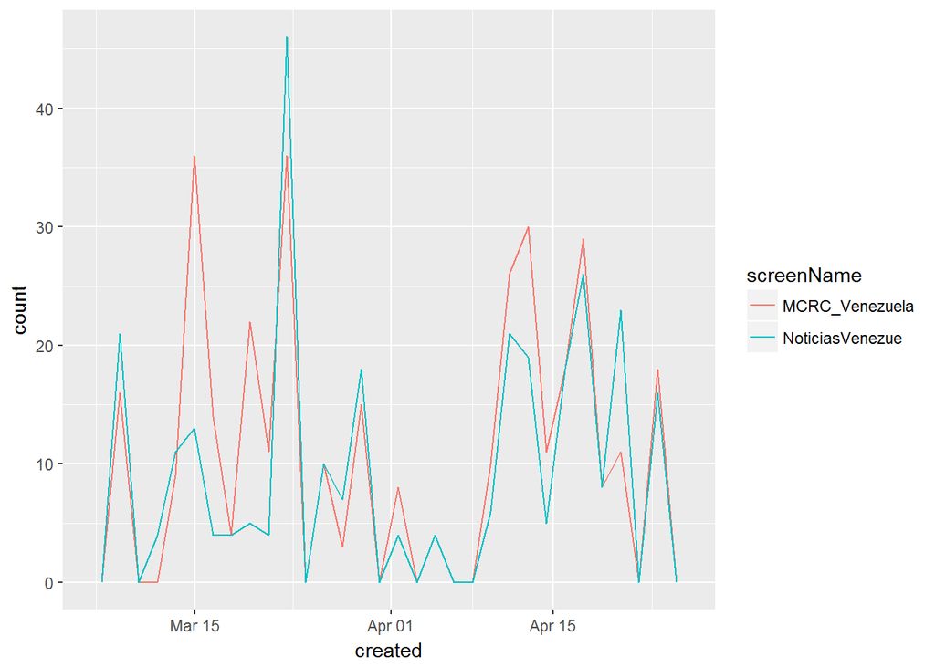

```r
qplot(created, data = MCRC_ts, geom="freqpoly", colour = screenName)
```

Similar to above but using ggplot Line Graph showing the number of tweets of the top 2 users, using ggplot

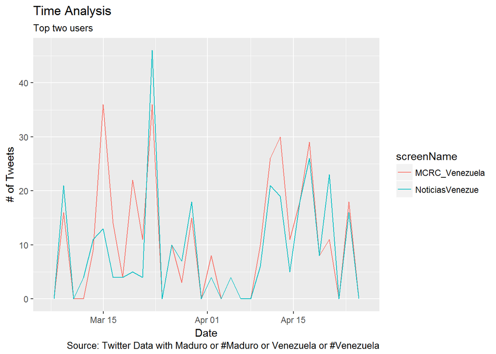

```r
ggplot(MCRC_ts, aes(x=created,colour=screenName))+geom_freqpoly()+labs(title= "Time Analysis", subtitle="Top two users",x="Date", y="# of Tweets", caption="Source: Twitter Data with Maduro or #Maduro or Venezuela or #Venezuela")
```

Stacked Bar chart showing the number of tweets of the top 2 users.

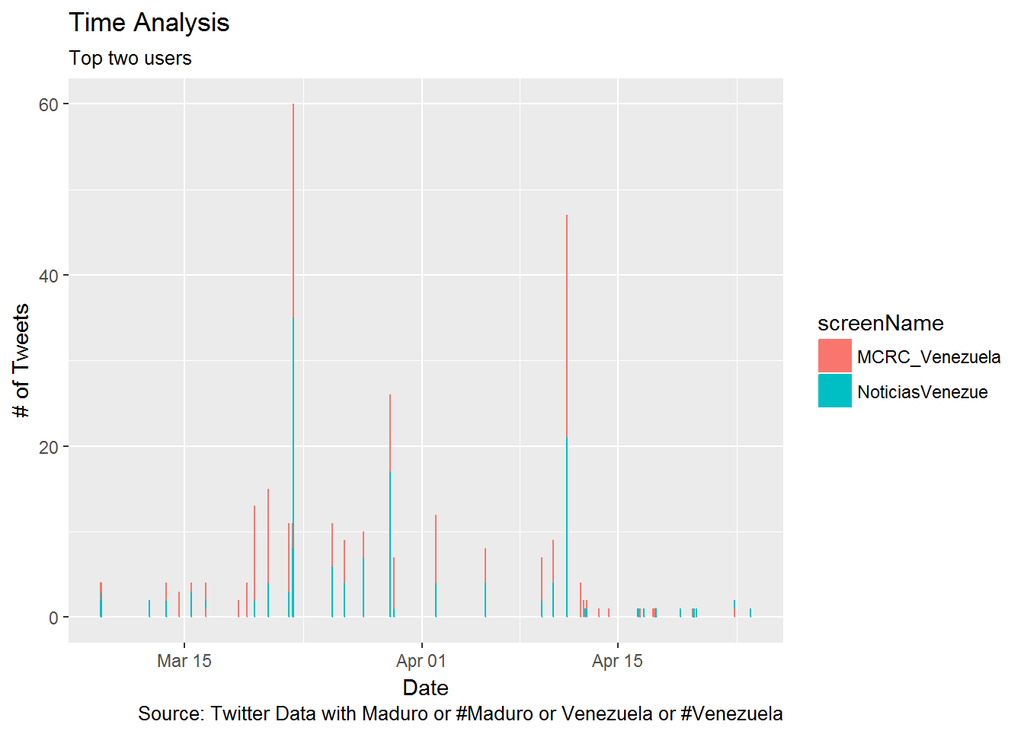

```r
ggplot(MCRC_ts, aes(x=created, colour=screenName))+
  geom_bar(aes(fill = screenName), width = 30)+labs(title= "Time Analysis", subtitle="Top two users",x="Date", y="# of Tweets", caption="Source: Twitter Data with Maduro or #Maduro or Venezuela or #Venezuela")
```

### Platforms

```r
commonPlatform_prop
```

```
## # A tibble: 516 x 3
##    Platform             freq   prop
##    <chr>               <int>  <dbl>
##  1 Twitter for Android 89809 47.5
##  2 Twitter Web Client  41293 21.9
##  3 Twitter for iPhone  27447 14.5
##  4 Twitter Lite         7147  3.78
##  5 TweetDeck            4642  2.46
##  6 Twitter for iPad     3584  1.90
##  7 Facebook             1145  0.606
##  8 Hootsuite            1110  0.588
##  9 IFTTT                1100  0.582
## 10 Mobile Web (M2)      1041  0.551
## # ... with 506 more rows
```

Creating a Pie Chart of all Platforms >1% First we need to aggragate all the Platforms that are under 1% into an Other Category

```r
df1 <- filter(commonPlatform_prop, prop>1)
df2 <- filter(commonPlatform_prop, prop<1)
sumfreq <- sum(df2$freq)
sumprop <- sum(df2$prop)
df3 <- data.frame(Platform='Other',freq = sumfreq, prop=sumprop)
df4 <- rbind(df1,df3)
```

Confirm that the prop of df4 = 100

```r
df4
```

```
## # A tibble: 7 x 3
##   Platform             freq  prop
##   <chr>               <int> <dbl>
## 1 Twitter for Android 89809 47.5
## 2 Twitter Web Client  41293 21.9
## 3 Twitter for iPhone  27447 14.5
## 4 Twitter Lite         7147  3.78
## 5 TweetDeck            4642  2.46
## 6 Twitter for iPad     3584  1.90
## 7 Other               14976  7.93
```

```r
sum(df4$prop)
```

```
## [1] 100
```

Creating first a bar chart. Source: http://www.sthda.com/english/wiki/ggplot2-pie-chart-quick-start-guide-r-software-and-data-visualization

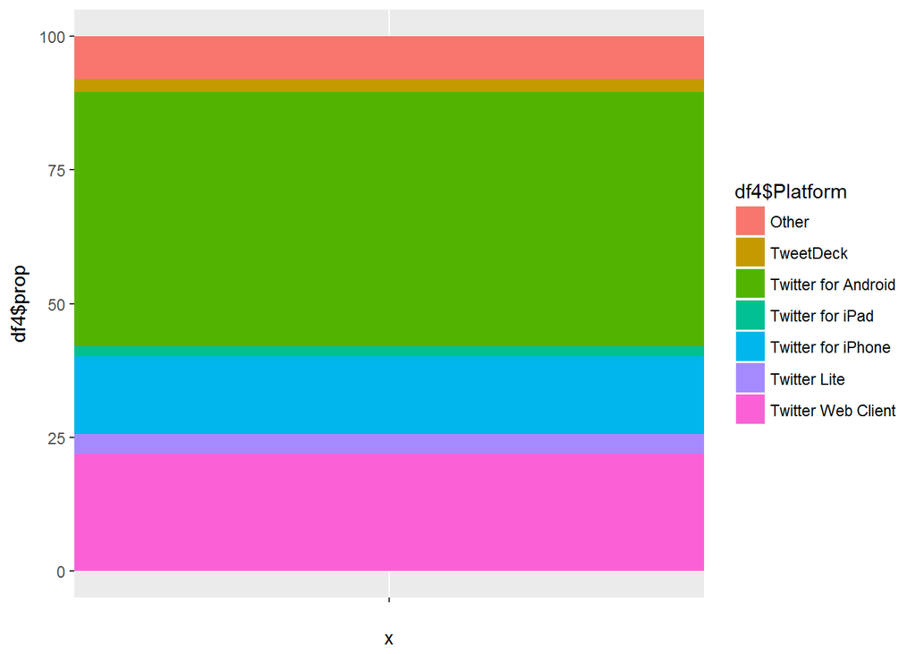

```r
platformBar<- ggplot(df4, aes(x="", y=df4$prop, fill=df4$Platform))+ geom_bar(width = 1, stat = "identity")
platformBar
```

Create the pie chart. Source: http://www.sthda.com/english/wiki/ggplot2-pie-chart-quick-start-guide-r-software-and-data-visualization

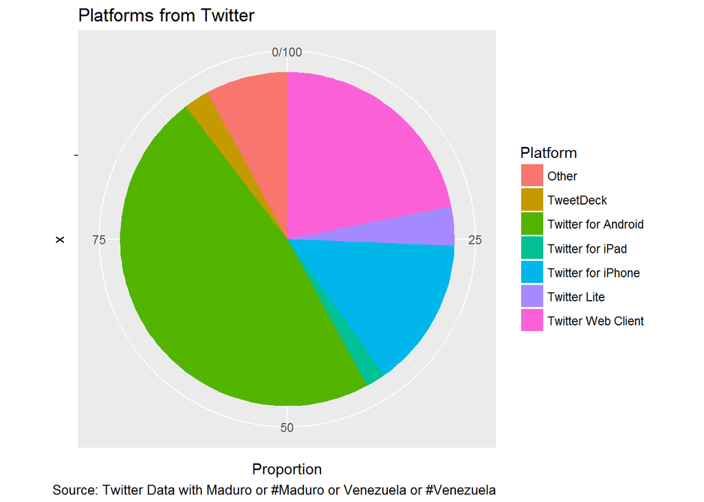

```r
platformPie <- platformBar + coord_polar("y", start=0)
platformPie + labs(title= "Platforms from Twitter",y="Proportion", fill="Platform", caption="Source: Twitter Data with Maduro or #Maduro or Venezuela or #Venezuela")
```

Creates a Dot Plot, showing the number of tweets by platform

[figure not shown]

```r
ggplot(arrange(df4,df4$freq), aes(x = freq, y = Platform, fill=Platform)) + geom_dotplot(binaxis = "y", stackgroups = FALSE, binwidth = .2, method = "histodot") + labs(title= "# of Tweets by Platform",y="Proportion", x="# of Tweets", fill="Platform", caption="Source: Twitter Data with Maduro or #Maduro or Venezuela or #Venezuela")
```

## Tweet Geo-location Analysis

We want to find out the location of the tweets based on the latitude and longtiude variables/columns. We removed the NAs using the drop_na tidyr function. Source: https://stackoverflow.com/questions/4862178/remove-rows-with-nas-missing-values-in-data-frame  
Another way to accomplish this task is to use the following dplyr filter function: test_lat_long <- filter(test_lat_long_1, !is.na(latitude), !is.na(longitude))

```r
test_lat_long1 <- drop_na(test_rmv_dups_sep2, latitude, longitude)
str(test_lat_long1)
```

```
## 'data.frame':    234 obs. of  17 variables:
##  $ text         : chr  "⒈ Hogares de la Patria\n⒉ Frente Amplio Venezuela Libre\n⒊ #YoSoyCampusLibertad\n⒋ "| __truncated__ "#mujer en Venezuela https://t.co/fWUFhFKcAk" "Buenas Tardes gente <ed> ½<ed>¸<ed> ½<ed>² ☀ a"| __truncated__ "El combo frao,  tas cla.  #tbt en Venezuela https://t.co/kzR6c…
##  $ favorited    : logi  FALSE FALSE FALSE FALSE FALSE FALSE ...
##  $ favoriteCount: num  0 0 0 0 0 0 0 1 0 0 ...
##  $ replyToSN    : chr  NA NA NA NA ...
##  $ created      : POSIXct, format: "2018-03-09 00:20:00" "2018-03-09 00:18:00" ...
##  $ truncated    : logi  TRUE FALSE FALSE FALSE FALSE TRUE ...
##  $ replyToSID   : chr  NA NA NA NA ...
##  $ id           : chr  "9.72e+17" "9.72e+17" "9.72e+17" "9.72e+17" ...
##  $ replyToUID   : chr  NA NA NA NA ...
##  $ Platform     : chr  "Es Tendencia en Venezuela" "Instagram" "Instagram" "Instagram" ...
##  $ screenName   : chr  "trendinaliaVE" "dj_viloria" "Bogoaccesorios" "IsraelRibas" ...
##  $ retweetCount : num  0 0 0 0 0 0 0 1 0 0 ...
##  $ isRetweet    : logi  FALSE FALSE FALSE FALSE FALSE FALSE ...
##  $ retweeted    : logi  FALSE FALSE FALSE FALSE FALSE FALSE ...
##  $ longitude    : chr  "-66.8983" "-65" "-67.59055556" "-65" ...
##  $ latitude     : chr  "10.496" "8" "10.24861111" "8" ...
##  $ source_data  : chr  "tweets.df500" "tweets.df500" "tweets.df3000" "tweets.df3000" ...
```

Save test_lat_long df as a CSV file to upload into ArcGIS online and created 2 maps.

```r
write.csv(test_lat_long1,file = paste(myPath,"test_lat_long.csv",sep=""), row.names = FALSE)
```

Create a variable that holds the frequency of the geographic data, and arranges it by descending order.

```r
lat_long_freq <- arrange(summarize(group_by(test_lat_long1,longitude,latitude),freq=n()),desc(freq))
lat_long_freq
```

```
## # A tibble: 75 x 3
## # Groups:   longitude [74]
##    longitude   latitude    freq
##    <chr>       <chr>      <int>
##  1 -66.8983    10.496       111
##  2 -65         8             12
##  3 -66.8792    10.488        11
##  4 -72.2333    7.7667         7
##  5 -66.9136    10.5056        6
##  6 -69.748     9.043          6
##  7 -71.6333    10.65          5
##  8 -63.5497    8.12222        4
##  9 -68.0255193 10.1234513     3
## 10 -74.0794    4.5997         3
## # ... with 65 more rows
```

Convert all the columns in our geographic frequency table into numeric values.

```r
lat_long_freq$longitude <- as.numeric(as.character(lat_long_freq$longitude))
lat_long_freq$latitude <- as.numeric(as.character(lat_long_freq$latitude))
lat_long_freq$freq <- as.numeric(as.integer(lat_long_freq$freq))
```

We can see that all columns are numeric type

```r
str(lat_long_freq)
```

[output not shown]

[output cut: 32 more lines]

[output not shown]

Checks that the sum of the frequency is equal to the number of rows in the original test_lat_long1 data frame

```r
sum(lat_long_freq$freq) == nrow(test_lat_long1)
```

```
## [1] TRUE
```

Using ggmap library, we obtain a map of Venezuela

```r
ven_map <- get_map(location = "Venezuela" , maptype = "satellite", zoom = 3)
```

Combining ggmap and ggplot we can overlay data points on the map. We are limited based on the zoom level specified in the previous line of code.

[figure not shown]

```r
ggmap(ven_map) + geom_point(aes(x = longitude, y = latitude), colour = "red", alpha = 0.1, size = 5, data = lat_long_freq)
```

For a more interactive map. We can use the leaflet plugin. Source: https://rstudio.github.io/leaflet/ We can overlay points based on the lat and long variables. We can also add an interactive label which shows the frequency

```r
m <- leaflet(lat_long_freq) %>% addTiles%>%
  addProviderTiles(providers$OpenStreetMap) %>%
  addCircles(lng = ~longitude, lat = ~latitude, radius=~freq*10, opacity=1, col="blue",  label=~as.character(freq), labelOptions = labelOptions(textsize = "14px"))

m
```

[interactive chart not shown]

The leaflet.extra library expands the leaflet functionality, allowing us to create heatmaps. We can overlay our previous layer where we added the circles, onto the heatmap, as well as adding interactive labels In this case hovering over the dots, will show the number of tweets coming from that location

```r
m <- leaflet(lat_long_freq) %>% addTiles%>%
  addProviderTiles(providers$OpenStreetMap) %>%
  addWebGLHeatmap(lng=~longitude, lat=~latitude, intensity = ~freq, size= 20, units = 'px') %>%
  addCircles(lng = ~longitude, lat = ~latitude, radius=~freq*10, opacity=1, col="blue",  label=~as.character(freq), labelOptions = labelOptions(textsize = "14px"))
m
```

[interactive chart not shown]

```r
test_lat_long1$longitude <- as.numeric(as.character(test_lat_long1$longitude))
test_lat_long1$latitude <- as.numeric(as.character(test_lat_long1$latitude))
m <- leaflet(test_lat_long1) %>% addTiles%>%
  addProviderTiles(providers$OpenStreetMap) %>%
  addCircleMarkers(lng = ~longitude, lat = ~latitude, radius=10, opacity=1, col="blue",  label=(~screenName),labelOptions = labelOptions(textsize = "14px"),clusterOptions = markerClusterOptions())
m
```

[interactive chart not shown]

We can also import the lat_long1 data frame Created maps using ArcGIS with tweets from 3/20/18:  
[Venezuelan Tweets Heat Map](https://github.com/perezba/rtweetvenba/blob/master/HeatMap_Ventweets.PNG?raw=true)  
[Venezuelan Tweets Platform](https://github.com/perezba/rtweetvenba/blob/master/Map_Ventweets.PNG)

## References and Notes:

- HTML file was knitted directly from the R script using rmarkdown render function:
- rmarkdown::render(paste(myPath,“ven_tweet.R”,sep=“”))
- Source: http://brooksandrew.github.io/simpleblog/articles/render-reports-directly-from-R-scripts/

## Change Tracker

- 3/26/18: Created HTML file to illustrate the process to collect, clean and manipulate twitter data
- 4/16/18: Added the graphs, and the plotting sections.